# ISLR_Ch3_LinearRegression_exercises_conceptual

Steve Newns

April 20, 2018

### Applied

**8. This question involves the use of simple linear regression on the Auto data set.** **(a) Use the lm() function to perform a simple linear regression with `mpg` as the response and `horsepower` as the predictor. Use the summary() function to print the results. Comment on the output. For example:**

```r
library(ISLR)
library(tidyverse)
library(ggplot2)
library(mosaic)
library(gridExtra)
data(Auto)

lm1 <- lm(mpg~horsepower,Auto)
msummary(lm1)
```

```
##              Estimate Std. Error t value Pr(>|t|)
## (Intercept) 39.935861   0.717499   55.66   <2e-16 ***
## horsepower  -0.157845   0.006446  -24.49   <2e-16 ***
##
## Residual standard error: 4.906 on 390 degrees of freedom
## Multiple R-squared:  0.6059, Adjusted R-squared:  0.6049
## F-statistic: 599.7 on 1 and 390 DF,  p-value: < 2.2e-16
```

- **i. Is there a relationship between the predictor and the response?**
  - The low $p$-value and *** significance level indicates that we can reject the null $H_0: \beta_1 = 0$ and say we there is evidence of a negative relationship between predictor `horsepower` and response `mpg`
- **ii. How strong is the relationship between the predictor and the response?**

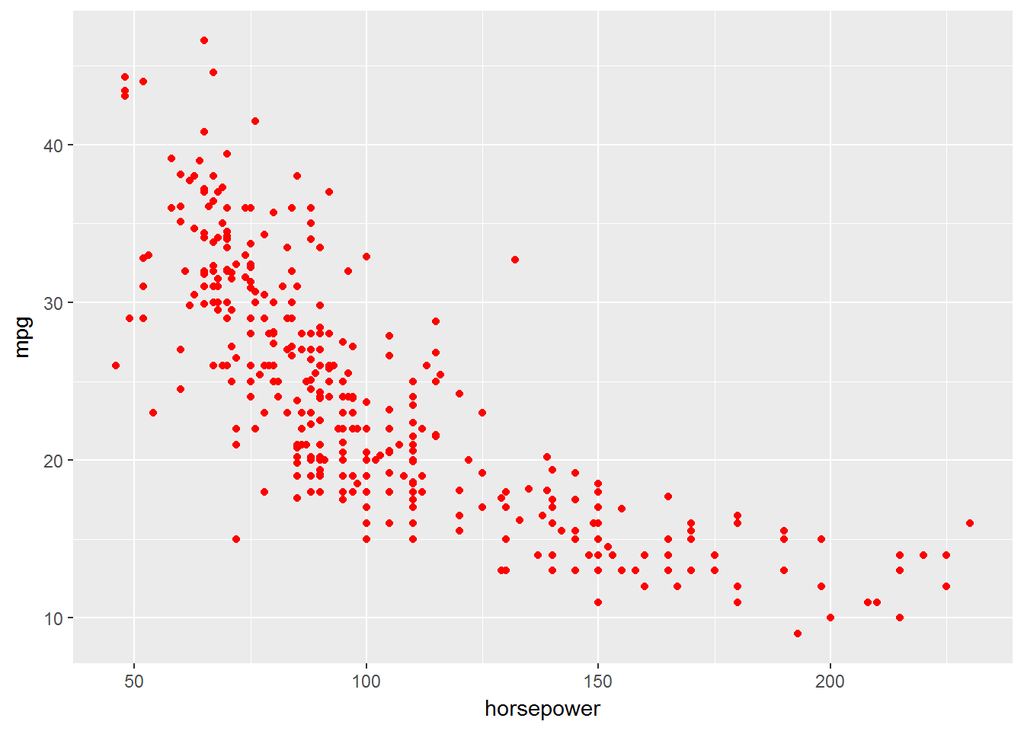

```r
library(ggplot2)
ggplot(Auto,aes(horsepower,mpg)) +
  geom_point(colour="red")
```

```r
cor(Auto$horsepower,Auto$mpg)
```

```
## [1] -0.7784268
```

```r
cor(Auto$horsepower,Auto$mpg)**2
```

```
## [1] 0.6059483
```

- So, we have a $R^2$ value of .6, which indicates a moderate relationship.
- **iii. Is the relationship between the predictor and the response positive or negative?**
  - It’s clearly negative
- **iv. What is the predicted `mpg` associated with a `horsepower` of 98? What are the associated 95 % confidence + prediction intervals?**
  - Using our regression formula `39.935861 - 0.157845(98)`, we get:

```
## [1] "predicted mpg for hp = 98: 24.467051"
```

```
## [1] "CI for predicted mpg for horsepower = 98: "
```

```
##        fit      lwr      upr
## 1 24.46708 23.97308 24.96108
```

```
## [1] "PI for predicted mpg for horsepower = 98"
```

```
##        fit     lwr      upr
## 1 24.46708 14.8094 34.12476
```

- We have 95% confidence that the interval `[23.97308, 24.96108]` contains the true parameter value for the predicted `mpg` value for a value of 98 for `horsepower` (i.e. that this is range for expected value of $y$ given a value for $x$, $E[y|x]$)
- We have 95% confidence that the interval `[14.8094, 34.12476]` would contain the next outcome value `mpg` for a value of 98 for `horsepower` (range for expected value of $y$ itself, $E[y]$)

**(b) Plot the response + predictor + use the `abline()` function to display the least squares regression line.**

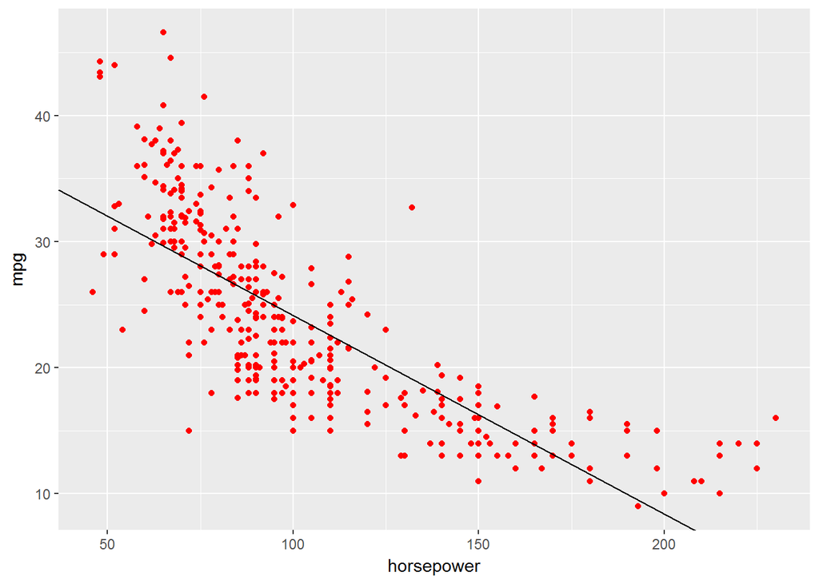

```r
#coef(lm1)
ggplot(Auto,aes(horsepower,mpg)) +
  geom_point(colour="red") +
  geom_abline(intercept = 39.9358610, slope = -0.1578447 )
```

**(c) Use `plot()` to produce diagnostic plots of the least squares regression fit. Comment on any problems you see with the fit.**

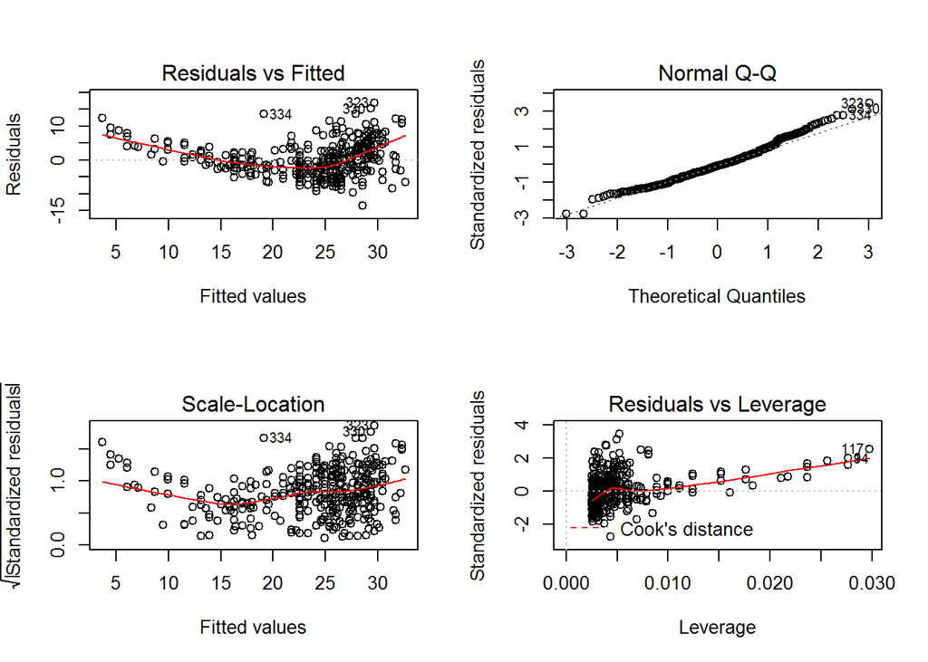

```r
par(mfrow=c(2,2))
plot(lm1)
```

- We can see a pattern in our residuals in both the Residuals and Scale-Location plot, indicating that our residuals are not identically and independently distributed (IID) and our relationship between the predictor and response is non-linear.
- In our Q-Q plot, we have the fitted quantiles are raising a bit too high at the higher end of theoretical quantiles, indicating a right skew.
- For our Residuals vs Leverage, we have what looks like 2-possible high levarage points (indicated by annotations of 117 and 94), and some outliers (> 2 or < -2 on the y-axis), which means these points are influencing our regression of `mpg` onto `horsepower`

**9. This question involves the use of multiple linear regression on the Auto data set.** **(a) Produce a scatterplot matrix which includes all of the variables in the data set.**

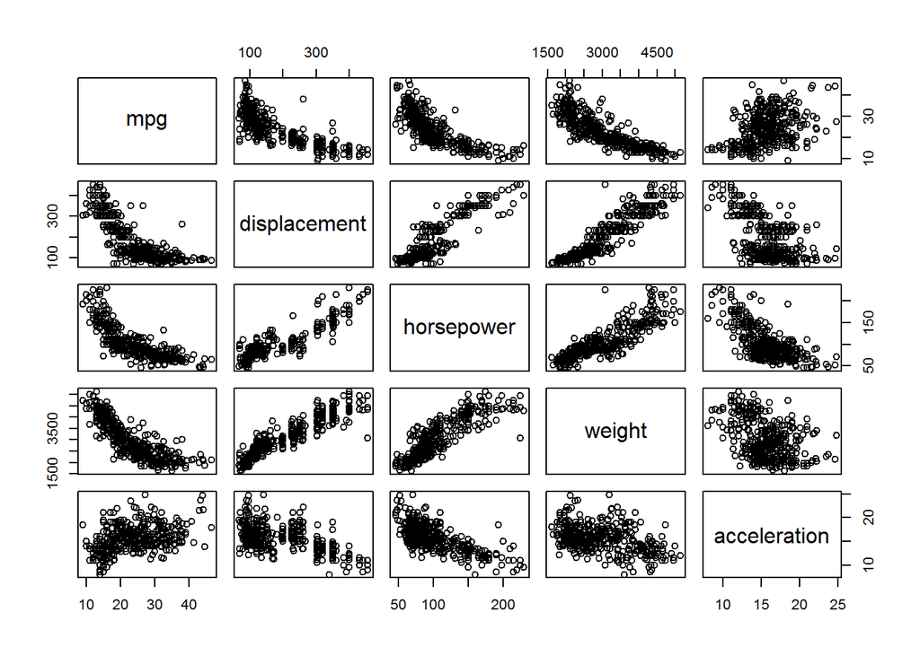

```r
pairs(~ mpg+displacement+horsepower+weight+acceleration, Auto)
```

**(b) Compute the matrix of correlations between the variables (exclude `name`, as its qualitative)**

```r
cor(dplyr::select(Auto,-name))
```

```
##                     mpg  cylinders displacement horsepower     weight
## mpg           1.0000000 -0.7776175   -0.8051269 -0.7784268 -0.8322442
## cylinders    -0.7776175  1.0000000    0.9508233  0.8429834  0.8975273
## displacement -0.8051269  0.9508233    1.0000000  0.8972570  0.9329944
## horsepower   -0.7784268  0.8429834    0.8972570  1.0000000  0.8645377
## weight       -0.8322442  0.8975273    0.9329944  0.8645377  1.0000000
## acceleration  0.4233285 -0.5046834   -0.5438005 -0.6891955 -0.4168392
## year          0.5805410 -0.3456474   -0.3698552 -0.4163615 -0.3091199
## origin        0.5652088 -0.5689316   -0.6145351 -0.4551715 -0.5850054
##              acceleration       year     origin
## mpg             0.4233285  0.5805410  0.5652088
## cylinders      -0.5046834 -0.3456474 -0.5689316
## displacement   -0.5438005 -0.3698552 -0.6145351
## horsepower     -0.6891955 -0.4163615 -0.4551715
## weight         -0.4168392 -0.3091199 -0.5850054
## acceleration    1.0000000  0.2903161  0.2127458
## year            0.2903161  1.0000000  0.1815277
## origin          0.2127458  0.1815277  1.0000000
```

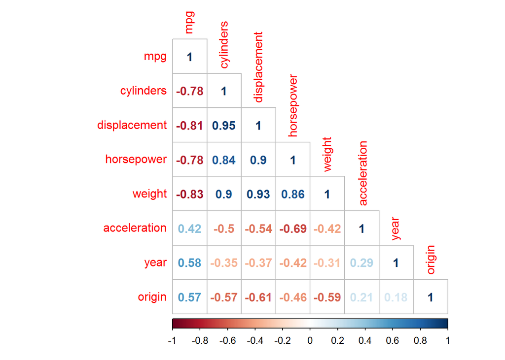

```r
library(corrplot)
corrplot(cor(dplyr::select(Auto,-name),
                  use="pairwise.complete.obs"), method = "number", type = "lower")
```

**(c) Perform a multiple linear regression with `mpg` as the response + all other variables except name as predictors. Use `summary()` to print the results. Comment on the output**

```r
lm2 <- lm(mpg~.-name,Auto)
msummary(lm2)
```

```
##                Estimate Std. Error t value Pr(>|t|)
## (Intercept)  -17.218435   4.644294  -3.707  0.00024 ***
## cylinders     -0.493376   0.323282  -1.526  0.12780
## displacement   0.019896   0.007515   2.647  0.00844 **
## horsepower    -0.016951   0.013787  -1.230  0.21963
## weight        -0.006474   0.000652  -9.929  < 2e-16 ***
## acceleration   0.080576   0.098845   0.815  0.41548
## year           0.750773   0.050973  14.729  < 2e-16 ***
## origin         1.426141   0.278136   5.127 4.67e-07 ***
##
## Residual standard error: 3.328 on 384 degrees of freedom
## Multiple R-squared:  0.8215, Adjusted R-squared:  0.8182
## F-statistic: 252.4 on 7 and 384 DF,  p-value: < 2.2e-16
```

- **i. Is there a relationship between the predictors and the response?**
  - There appears to be a relationship between `mpg` and *some* predictors = `weight`,`year`,`origin`, and some `displacement`
- **ii. Which predictors appear to have a statistically significant relationship to the response?**
  - Very sig = `weight`,`year`,`origin`, Moderately = `displacement`
- **iii. What does the coefficient for `year` suggest?**
  - It suggests that for each year increase, we have a .75 unit increase in `mpg`
- **(d) Produce diagnostic plots of the linear regression fit. Comment on any problems you see with the fit. Do the residual plots suggest any unusually large outliers? Does the leverage plot identify any observations with unusually high leverage?**

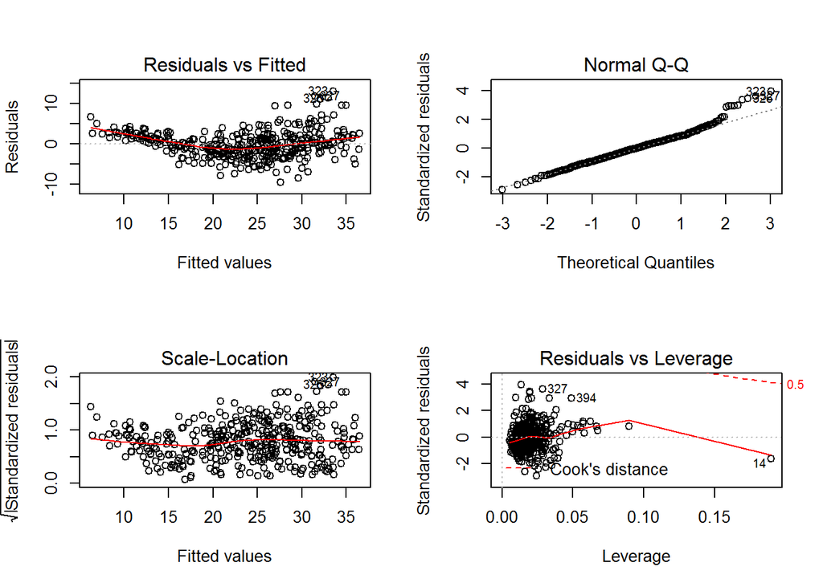

```r
par(mfrow=c(2,2))
plot(lm2)
```

- There may be a *slight* pattern in Residuals vs. Fitted, but it is not apparant in Scale-Location, indicating that we are probably able to say that our residuals are identically and independently distributed (IID) and our relationship between the predictor and response is linear.
- In our Q-Q plot, we have the fitted quantiles are raising a bit too high at the higher end of theoretical quantiles, indicating a right skew.
- For our Residuals vs Leverage, we have a couple outliers (> 2 or < -2 on the y-axis) and a high levarage point (14), which means these points are influencing our regression of `mpg` onto `horsepower`
- **(e) Use * and : symbols to fit linear regression models w/ interaction effects. Do any interactions appear to be statistically significant?**

```r
lm3 <- lm(mpg~.-name+cylinders*(.-name),Auto)
lm4 <- lm(mpg~.-name+displacement*(.-name),Auto)
lm5 <- lm(mpg~.-name+horsepower*(.-name),Auto)
lm6 <- lm(mpg~.-name+weight*(.-name),Auto)
lm7 <- lm(mpg~.-name+acceleration*(.-name),Auto)
lm8 <- lm(mpg~.-name+year*(.-name),Auto)
lm9 <- lm(mpg~.-name+origin*(.-name),Auto)
msummary(lm3)
```

```
##                          Estimate Std. Error t value Pr(>|t|)
## (Intercept)            -2.902e+01  1.485e+01  -1.954 0.051483 .
## cylinders               3.090e+00  2.702e+00   1.143 0.253571
## displacement            4.810e-03  2.408e-02   0.200 0.841758
## horsepower             -1.777e-01  5.472e-02  -3.248 0.001267 **
## weight                 -1.006e-02  2.457e-03  -4.093 5.20e-05 ***
## acceleration           -1.020e-02  2.989e-01  -0.034 0.972804
## year                    1.336e+00  1.654e-01   8.078 8.93e-15 ***
## origin                 -2.217e+00  1.381e+00  -1.606 0.109192
## cylinders:displacement  3.982e-04  3.632e-03   0.110 0.912762
## cylinders:horsepower    1.918e-02  8.013e-03   2.393 0.017185 *
## cylinders:weight        8.602e-04  3.624e-04   2.374 0.018113 *
## cylinders:acceleration  1.166e-03  5.431e-02   0.021 0.982878
## cylinders:year         -1.164e-01  3.143e-02  -3.703 0.000245 ***
## cylinders:origin        7.242e-01  3.182e-01   2.276 0.023421 *
##
## Residual standard error: 2.865 on 378 degrees of freedom
## Multiple R-squared:  0.8697, Adjusted R-squared:  0.8652
## F-statistic: 194.1 on 13 and 378 DF,  p-value: < 2.2e-16
```

```r
msummary(lm4)
```

```
##                             Estimate Std. Error t value Pr(>|t|)
## (Intercept)               -2.969e+01  9.208e+00  -3.224 0.001374 **
## cylinders                  5.963e-01  6.337e-01   0.941 0.347315
## displacement               7.124e-02  4.552e-02   1.565 0.118384
## horsepower                -9.923e-02  3.180e-02  -3.120 0.001947 **
## weight                    -7.921e-03  1.442e-03  -5.494 7.24e-08 ***
## acceleration               8.465e-02  1.799e-01   0.471 0.638189
## year                       1.104e+00  9.861e-02  11.197  < 2e-16 ***
## origin                    -8.692e-01  9.395e-01  -0.925 0.355498
## cylinders:displacement     1.507e-04  2.874e-03   0.052 0.958210
## displacement:horsepower    1.662e-04  1.030e-04   1.614 0.107419
## displacement:weight        1.539e-05  4.605e-06   3.341 0.000917 ***
## displacement:acceleration -5.242e-04  8.972e-04  -0.584 0.559352
## displacement:year         -2.042e-03  5.206e-04  -3.923 0.000104 ***
## displacement:origin        1.245e-02  8.073e-03   1.542 0.123935
##
## Residual standard error: 2.836 on 378 degrees of freedom
## Multiple R-squared:  0.8724, Adjusted R-squared:  0.868
## F-statistic: 198.7 on 13 and 378 DF,  p-value: < 2.2e-16
```

```r
msummary(lm5)
```

```
##                           Estimate Std. Error t value Pr(>|t|)
## (Intercept)             -5.463e+01  1.304e+01  -4.191 3.46e-05 ***
## cylinders                2.560e-01  1.155e+00   0.222  0.82471
## displacement            -1.245e-02  2.022e-02  -0.616  0.53846
## horsepower               3.621e-01  1.307e-01   2.772  0.00585 **
## weight                  -7.572e-03  1.674e-03  -4.522 8.20e-06 ***
## acceleration             1.785e-01  2.180e-01   0.819  0.41336
## year                     1.381e+00  1.404e-01   9.836  < 2e-16 ***
## origin                   1.216e+00  1.147e+00   1.060  0.28970
## cylinders:horsepower     1.104e-03  9.759e-03   0.113  0.90996
## displacement:horsepower  2.132e-05  1.411e-04   0.151  0.88002
## horsepower:weight        3.440e-05  1.196e-05   2.878  0.00423 **
## horsepower:acceleration -4.040e-03  2.286e-03  -1.767  0.07804 .
## horsepower:year         -6.535e-03  1.392e-03  -4.695 3.74e-06 ***
## horsepower:origin       -6.031e-03  1.365e-02  -0.442  0.65889
##
## Residual standard error: 2.81 on 378 degrees of freedom
## Multiple R-squared:  0.8747, Adjusted R-squared:  0.8704
## F-statistic: 202.9 on 13 and 378 DF,  p-value: < 2.2e-16
```

```r
msummary(lm6)
```

```
##                       Estimate Std. Error t value Pr(>|t|)
## (Intercept)         -6.019e+01  1.798e+01  -3.348 0.000897 ***
## cylinders           -3.003e-01  1.517e+00  -0.198 0.843185
## displacement        -2.941e-02  2.924e-02  -1.006 0.315071
## horsepower          -1.078e-01  5.141e-02  -2.098 0.036568 *
## weight               9.739e-03  6.191e-03   1.573 0.116523
## acceleration         2.677e-01  2.942e-01   0.910 0.363516
## year                 1.551e+00  1.873e-01   8.280 2.15e-15 ***
## origin              -2.157e+00  1.483e+00  -1.455 0.146447
## cylinders:weight     1.836e-04  4.469e-04   0.411 0.681450
## displacement:weight  1.131e-05  8.148e-06   1.389 0.165755
## horsepower:weight    1.758e-05  1.402e-05   1.254 0.210627
## weight:acceleration -6.998e-05  1.014e-04  -0.690 0.490562
## weight:year         -2.841e-04  6.664e-05  -4.263 2.55e-05 ***
## weight:origin        1.194e-03  6.252e-04   1.910 0.056834 .
##
## Residual standard error: 2.863 on 378 degrees of freedom
## Multiple R-squared:  0.8699, Adjusted R-squared:  0.8655
## F-statistic: 194.5 on 13 and 378 DF,  p-value: < 2.2e-16
```

```r
msummary(lm7)
```

```
##                             Estimate Std. Error t value Pr(>|t|)
## (Intercept)               76.5903735 23.0970518   3.316 0.001001 **
## cylinders                 -5.3128525  1.5031883  -3.534 0.000459 ***
## displacement               0.0234541  0.0371606   0.631 0.528321
## horsepower                 0.0170220  0.0518838   0.328 0.743034
## weight                     0.0028788  0.0023738   1.213 0.225986
## acceleration              -5.9682540  1.4352007  -4.158 3.97e-05 ***
## year                      -0.3491239  0.2878381  -1.213 0.225919
## origin                    -6.5692825  1.9255394  -3.412 0.000715 ***
## cylinders:acceleration     0.3498158  0.1006585   3.475 0.000570 ***
## displacement:acceleration -0.0022950  0.0024665  -0.930 0.352738
## horsepower:acceleration   -0.0041802  0.0034101  -1.226 0.221036
## weight:acceleration       -0.0004508  0.0001550  -2.908 0.003855 **
## acceleration:year          0.0707599  0.0179812   3.935 9.89e-05 ***
## acceleration:origin        0.4584646  0.1184094   3.872 0.000127 ***
##
## Residual standard error: 2.967 on 378 degrees of freedom
## Multiple R-squared:  0.8603, Adjusted R-squared:  0.8555
## F-statistic:   179 on 13 and 378 DF,  p-value: < 2.2e-16
```

```r
msummary(lm8)
```

```
##                     Estimate Std. Error t value Pr(>|t|)
## (Intercept)       -6.295e+01  3.955e+01  -1.592  0.11231
## cylinders         -3.236e+00  6.276e+00  -0.516  0.60646
## displacement      -2.242e-01  1.389e-01  -1.614  0.10739
## horsepower         5.538e-01  2.500e-01   2.215  0.02734 *
## weight             3.361e-02  1.256e-02   2.677  0.00775 **
## acceleration      -3.830e+00  1.778e+00  -2.154  0.03190 *
## year               1.391e+00  5.179e-01   2.686  0.00756 **
## origin             4.135e-01  5.526e+00   0.075  0.94038
## cylinders:year     4.160e-02  8.284e-02   0.502  0.61585
## displacement:year  3.087e-03  1.857e-03   1.663  0.09720 .
## horsepower:year   -7.924e-03  3.383e-03  -2.342  0.01968 *
## weight:year       -5.225e-04  1.689e-04  -3.093  0.00213 **
## acceleration:year  5.041e-02  2.344e-02   2.151  0.03211 *
## year:origin        8.573e-03  7.122e-02   0.120  0.90426
##
## Residual standard error: 3.017 on 378 degrees of freedom
## Multiple R-squared:  0.8555, Adjusted R-squared:  0.8505
## F-statistic: 172.2 on 13 and 378 DF,  p-value: < 2.2e-16
```

```r
msummary(lm9)
```

```
##                       Estimate Std. Error t value Pr(>|t|)
## (Intercept)          10.495524  10.100557   1.039 0.299421
## cylinders            -1.688144   0.667998  -2.527 0.011906 *
## displacement         -0.023367   0.021376  -1.093 0.275028
## horsepower            0.040812   0.031299   1.304 0.193042
## weight               -0.002016   0.001640  -1.229 0.219683
## acceleration         -0.765094   0.224332  -3.411 0.000718 ***
## year                  0.509361   0.109103   4.669 4.22e-06 ***
## origin              -12.825675   6.101034  -2.102 0.036196 *
## cylinders:origin      0.744185   0.454583   1.637 0.102447
## displacement:origin   0.020163   0.017604   1.145 0.252773
## horsepower:origin    -0.048688   0.024130  -2.018 0.044318 *
## weight:origin        -0.001911   0.001211  -1.577 0.115562
## acceleration:origin   0.428624   0.140570   3.049 0.002456 **
## year:origin           0.130813   0.061983   2.110 0.035475 *
##
## Residual standard error: 3.036 on 378 degrees of freedom
## Multiple R-squared:  0.8537, Adjusted R-squared:  0.8487
## F-statistic: 169.7 on 13 and 378 DF,  p-value: < 2.2e-16
```

- cylinders:year
- displacement:weight
- displacement:year
- horsepower:year
- weight:year
- cylinders:acceleration
- weight:acceleration
- acceleration:year
- acceleration:origin
- **(f) Try a few different transformations of the variables, such as $log(X)$, $sqrt{X}$, $X^2$. Comment on your findings.**

```r
msummary(lm(mpg ~ sqrt(displacement) + . - name - cylinders - origin - acceleration, Auto))
```

```
##                      Estimate Std. Error t value Pr(>|t|)
## (Intercept)        15.7146178  4.6466203   3.382 0.000793 ***
## sqrt(displacement) -4.9722634  0.4745244 -10.478  < 2e-16 ***
## displacement        0.1705449  0.0167812  10.163  < 2e-16 ***
## horsepower         -0.0443259  0.0100789  -4.398 1.42e-05 ***
## weight             -0.0044234  0.0005552  -7.966 1.85e-14 ***
## year                0.7804940  0.0464173  16.815  < 2e-16 ***
##
## Residual standard error: 3.034 on 386 degrees of freedom
## Multiple R-squared:  0.8508, Adjusted R-squared:  0.8489
## F-statistic: 440.3 on 5 and 386 DF,  p-value: < 2.2e-16
```

```r
msummary(lm(mpg ~ log(displacement) + . - name - cylinders - acceleration - origin, Auto))
```

```
##                     Estimate Std. Error t value Pr(>|t|)
## (Intercept)        5.020e+01  7.301e+00   6.875 2.50e-11 ***
## log(displacement) -1.644e+01  1.617e+00 -10.169  < 2e-16 ***
## displacement       7.964e-02  9.012e-03   8.837  < 2e-16 ***
## horsepower        -3.990e-02  1.003e-02  -3.980 8.23e-05 ***
## weight            -4.529e-03  5.568e-04  -8.133 5.76e-15 ***
## year               7.862e-01  4.676e-02  16.813  < 2e-16 ***
##
## Residual standard error: 3.054 on 386 degrees of freedom
## Multiple R-squared:  0.8489, Adjusted R-squared:  0.8469
## F-statistic: 433.6 on 5 and 386 DF,  p-value: < 2.2e-16
```

```r
msummary(lm(mpg ~ I(displacement^2) + . - displacement - name - acceleration  - cylinders, Auto)) # now origin matters, lower R2
```

```
##                     Estimate Std. Error t value Pr(>|t|)
## (Intercept)       -1.436e+01  3.999e+00  -3.590 0.000373 ***
## I(displacement^2)  5.491e-05  9.546e-06   5.752 1.79e-08 ***
## horsepower        -4.797e-02  1.105e-02  -4.343 1.80e-05 ***
## weight            -6.804e-03  4.745e-04 -14.339  < 2e-16 ***
## year               7.654e-01  4.912e-02  15.584  < 2e-16 ***
## origin             1.421e+00  2.543e-01   5.586 4.39e-08 ***
##
## Residual standard error: 3.216 on 386 degrees of freedom
## Multiple R-squared:  0.8324, Adjusted R-squared:  0.8303
## F-statistic: 383.5 on 5 and 386 DF,  p-value: < 2.2e-16
```

**10. This question should be answered using the Carseats data set.** **(a) Fit a multiple regression model to predict `Sales` using `Price`, `Urban`, and `US`.**

```r
data("Carseats")
lm10 <- lm(Sales~Price+Urban+US,Carseats)
msummary(lm10)
```

```
##              Estimate Std. Error t value Pr(>|t|)
## (Intercept) 13.043469   0.651012  20.036  < 2e-16 ***
## Price       -0.054459   0.005242 -10.389  < 2e-16 ***
## UrbanYes    -0.021916   0.271650  -0.081    0.936
## USYes        1.200573   0.259042   4.635 4.86e-06 ***
##
## Residual standard error: 2.472 on 396 degrees of freedom
## Multiple R-squared:  0.2393, Adjusted R-squared:  0.2335
## F-statistic: 41.52 on 3 and 396 DF,  p-value: < 2.2e-16
```

**(b) Provide an interpretation of each coefficient in the model. Be careful-some of the variables in the model are qualitative!**

**(c) Write out the model in equation form, being careful to handle the qualitative variables properly.**

**(d) For which of the predictors can you reject the null hypothesis $H_0 : \beta_j = 0$?**

- `Price` and `USyes`

**(e) On the basis of your response to the previous question, fit a smaller model that only uses the predictors for which there is evidence of association with the outcome.**

```r
lm11 <- lm(Sales~Price+US,Carseats)
msummary(lm11)
```

```
##             Estimate Std. Error t value Pr(>|t|)
## (Intercept) 13.03079    0.63098  20.652  < 2e-16 ***
## Price       -0.05448    0.00523 -10.416  < 2e-16 ***
## USYes        1.19964    0.25846   4.641 4.71e-06 ***
##
## Residual standard error: 2.469 on 397 degrees of freedom
## Multiple R-squared:  0.2393, Adjusted R-squared:  0.2354
## F-statistic: 62.43 on 2 and 397 DF,  p-value: < 2.2e-16
```

**(f) How well do the models in (a) and (e) fit the data?**

- 2nd model fits barely better ($R^2 = .2354$ vs. $.2335$)

**(g) Using the model from (e), obtain 95 % confidence intervals for the coefficient(s).**

```r
confint(lm11)
```

```
##                   2.5 %      97.5 %
## (Intercept) 11.79032020 14.27126531
## Price       -0.06475984 -0.04419543
## USYes        0.69151957  1.70776632
```

**(h) Is there evidence of outliers or high leverage observations in the model from (e)?**

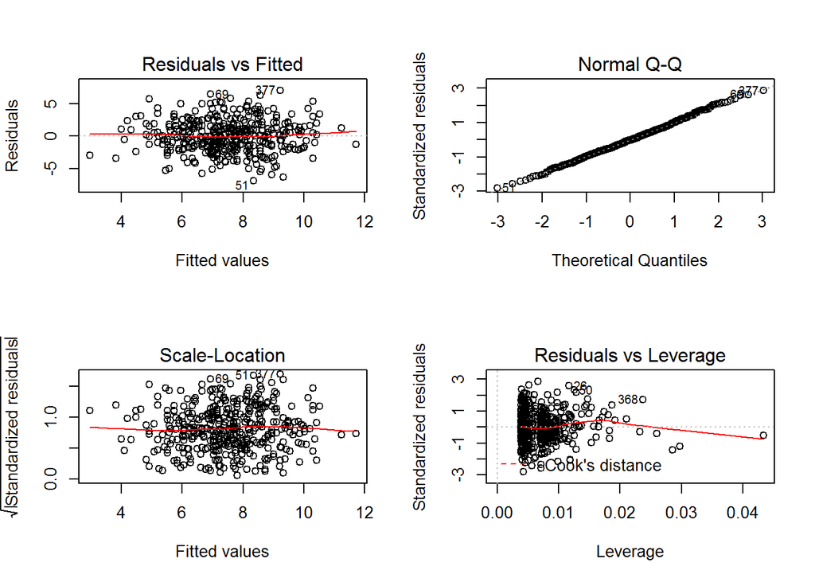

```r
par(mfrow=c(2,2))
plot(lm11)
```

- 1 high leverage point, but our data appears to be normal and our residuals appear to be IID

**11. In this problem we will investigate the $t$-statistic for the null $H_0: \beta = 0$ in simple linear regression without an intercept. To begin, generate a predictor $x$ and a response $y$ as follows.**

```r
set.seed(1)
x <- rnorm(100)
y <- 2*x+rnorm(100)
```

**(a) Perform a simple linear regression of $y$ onto $x$, w/out an intercept. Report coefficient estimate $\hat{\beta}$, the Std. Error of this coefficient estimate, + the $t$-statistic + $p$-value associated w/ the null. Comment on these results.**

```r
# regression w/out intercept
msummary(lm(y~x+0))
```

```
##   Estimate Std. Error t value Pr(>|t|)
## x   1.9939     0.1065   18.73   <2e-16 ***
##
## Residual standard error: 0.9586 on 99 degrees of freedom
## Multiple R-squared:  0.7798, Adjusted R-squared:  0.7776
## F-statistic: 350.7 on 1 and 99 DF,  p-value: < 2.2e-16
```

- We have $\hat{\beta}$ = `1.9939`, `Std. Error = .1065`, $t$ = `18.73` (large = good for deviation), and $p$-value = `2e-16` (very significant)
- We have a p-value (probability of observing any value >= |$t$| in absolute value, assuming $\beta$ = 0) that is very low, which means that we can reject the null that there is no relationship between predictor + response (reject that $H_0: \beta = 0$) and the difference are not due to chance.

**(b) Now perform a simple linear regression of $x$ onto $y$ without an intercept, and report the coefficient estimate, its standard error, and the corresponding $t$-statistic and $p$-values associated with the null hypothesis $H_0: \beta = 0$. Comment on these results.**

```r
msummary(lm(x~y+0))
```

```
##   Estimate Std. Error t value Pr(>|t|)
## y  0.39111    0.02089   18.73   <2e-16 ***
##
## Residual standard error: 0.4246 on 99 degrees of freedom
## Multiple R-squared:  0.7798, Adjusted R-squared:  0.7776
## F-statistic: 350.7 on 1 and 99 DF,  p-value: < 2.2e-16
```

- We have $\beta$ = `.3911`, Std. Error = `02089`, $t$ = `18.73` (***same as above***), and $p$-value = `2e-16` (very significant)
- We have a $p$-value (probability of observing any value >= |$t$| in absolute value, assuming $\beta$ = 0) that is very low, which means that we can reject the null that there is no relationship between predictor + response (reject that $H_0: \beta = 0$) and the difference are not due to chance.

**(c) What is the relationship between the results obtained in (a) and (b)?**

- While we have different coefficient estimates, we’ve obtained the same $t$-stastic and same $p$-value, meaning that the evidence to reject the null was the same in both models

**(d) For the regression of $Y$ onto $X$ without an intercept, the t-statistic for $H_0: \beta = 0$ takes the form $\frac {\hat{\beta}} {SE(\hat{\beta})}$, where $\hat{\beta}$ = given by (3.38) $\hat{\beta} = \frac {\sum_{i=1}^{n}(x_iy_i)} {\sum_{i`=1}^{n}(x_{i`}^2)}$, and where $SE(\hat{\beta}) = \sqrt{\frac {\sum_{i=1}^{n}(y_i - x_i\hat{\beta})^2} {(n-1)\sum_{i`=1}^{n}(x_{i`}^2)}}$ (slightly different formula from Sections 3.1.1 + 3.1.2, since here we’re performing regression w/out an intercept.) Show algebraically + confirm in R, that the $t$-statistic can be written as**

- $\frac {\sqrt{n-1}\sum_{i=1}^{n}(x_iy_i)} {\sqrt{\sum_{i=1}^{n}(x_{i}^2)\sum_{i`=1}^{n}(y_{i`}^2) - \sum_{i`=1}^{n}(x_i`y_i`)}}$

```r
b_hat_x <- sum(x*y)/(sum(x^2))
(stderr_b_hat_x <- sqrt(sum((y-x*b_hat_x)^2)/((length(x)-1)*sum(x^2))))
```

```
## [1] 0.1064767
```

```r
b_hat_y <- sum(y*x)/(sum(y^2))
(stderr_b_hat_y <- sqrt(sum((x-y*b_hat_y)^2)/((length(y)-1)*sum(y^2))))
```

```
## [1] 0.02088625
```

```r
(t_y <- (sum(x*y)/(sum(x^2)))/sqrt(sum((y-x*b_hat_x)^2)/((length(x)-1)*sum(x^2))))
```

```
## [1] 18.72593
```

```r
(t_y <- (sum(x*y)*sqrt(length(y)-1))/sqrt(sum(x^2)*sum(y^2) - sum(x*y)^2))
```

```
## [1] 18.72593
```

**(e) Using the results from (d), argue that the $t$-statistic for the regression of $y$ onto $x$ is the same as the $t$-statistic for the regression of x onto y.**

- Since $t = \frac {\hat{\beta}} {SE(\hat{\beta})}$, and we have different $\beta$ values for each, we can use the different values for SE(B) to get the same t-statistic

```r
(t_x <- b_hat_x/stderr_b_hat_x)
```

```
## [1] 18.72593
```

```r
(t_y <- b_hat_y/stderr_b_hat_y)
```

```
## [1] 18.72593
```

**(f) In R, show that when regression is performed with an intercept, the t-statistic for $H_0 : \beta_1$ = 0 is the same for the regression of $y$ onto $x$ as it is for the regression of $x$ onto $y$.**

```r
x_on_y <- lm(x~y)
msummary(x_on_y)
```

```
##             Estimate Std. Error t value Pr(>|t|)
## (Intercept)  0.03880    0.04266    0.91    0.365
## y            0.38942    0.02099   18.56   <2e-16 ***
##
## Residual standard error: 0.4249 on 98 degrees of freedom
## Multiple R-squared:  0.7784, Adjusted R-squared:  0.7762
## F-statistic: 344.3 on 1 and 98 DF,  p-value: < 2.2e-16
```

```r
paste0('intercept t statistic: ',x_on_y$coefficients[1]/.04266)
```

```
## [1] "intercept t statistic: 0.909609479346597"
```

```r
paste0('predictor t statistic: ',x_on_y$coefficients[2]/.02099)
```

```
## [1] "predictor t statistic: 18.5528587699043"
```

```r
y_on_x <- lm(y~x)
msummary(y_on_x)
```

```
##             Estimate Std. Error t value Pr(>|t|)
## (Intercept) -0.03769    0.09699  -0.389    0.698
## x            1.99894    0.10773  18.556   <2e-16 ***
##
## Residual standard error: 0.9628 on 98 degrees of freedom
## Multiple R-squared:  0.7784, Adjusted R-squared:  0.7762
## F-statistic: 344.3 on 1 and 98 DF,  p-value: < 2.2e-16
```

```r
paste0('intercept t statistic: ',y_on_x$coefficients[1]/.09699)
```

```
## [1] "intercept t statistic: -0.388623712833866"
```

```r
paste0('predictor t statistic: ',y_on_x$coefficients[2]/.10773)
```

```
## [1] "predictor t statistic: 18.5550878476568"
```

**12. This problem involves simple linear regression without an intercept.** **(a) Recall the coefficient estimate $\hat{\beta}$ for linear regression of $Y$ onto $X$ w/out an intercept is given by $\frac {\sum_{i=1}^{n}(x_iy_i)} {\sum_{i`=1}^{n}(x_{i`}^2)}$. Under what circumstance is the coefficient estimate for the regression of $X$ onto $Y$ the same as the coefficient estimate for the regression of $Y$ onto $X$?**

- Looking @ the formulas for both $\hat{\beta}$ values, the numerator is the same $\sum_{i=1}^{n}(x_iy_i)$, but with different denominators, $\sum_{i=1}^{n}y_i^2$ vs $\sum_{i=1}^{n}x_i^2$. So, when those 2 values are equal, then we get the same $\hat{\beta}$ for each regression.

**(b) Generate an example in R with n = 100 observations in which the coefficient estimate for the regression of X onto Y is *different* from the coefficient estimate for the regression of Y onto X.**

```r
set.seed(1)
x <- rnorm(100)
y <- rnorm(100)
summary(lm(y~x+0))$coefficients
```

```
##       Estimate Std. Error     t value  Pr(>|t|)
## x -0.006123917  0.1064767 -0.05751413 0.9542516
```

```r
summary(lm(x~y+0))$coefficients
```

```
##       Estimate Std. Error     t value  Pr(>|t|)
## y -0.005455947 0.09486272 -0.05751413 0.9542516
```

**(c) Generate an example in R with $n$= 100 observations in which the coefficient estimate for the regression of $X$ onto $Y$ is the same as the coefficient estimate for the regression of $Y$ onto $X$.**

```r
set.seed(1)
x <- rnorm(100)
y <- rev(x)
summary(lm(y~x+0))$coefficients
```

```
##     Estimate Std. Error   t value  Pr(>|t|)
## x 0.03785107  0.1004318 0.3768835 0.7070668
```

```r
summary(lm(x~y+0))$coefficients
```

```
##     Estimate Std. Error   t value  Pr(>|t|)
## y 0.03785107  0.1004318 0.3768835 0.7070668
```

**13. In this exercise you will create some simulated data + will fit simple linear regression models to it. Make sure to use set.seed(1) prior to starting part (a) to ensure consistent results.** **(a) Using rnorm(), create a vector, `x`, containing 100 observations drawn from an $N(0, 1)$ distribution. This represents a feature, $X$.**

```r
set.seed(1)
x <- rnorm(100) # N(0,1) by default
```

**(b) Using the rnorm() function, create a vector, `eps`, containing 100 observations drawn from an $N(0, 0.25)$ distribution i.e. a normal distribution with $\mu$ = 0 and variance $\sigma$ = 0.25.**

```r
eps <- rnorm(100,sd=sqrt(.25))
```

**(c) Using `x` and `eps`, generate a vector `y` according to the model $Y = -1 +0.5X + \epsilon$. What is the length of the vector `y`? What are the values of $\beta_0$ and $\beta_1$ in this linear model?**

```r
y <- -1 + .5*x + eps
head(y)
```

```
## [1] -1.6234102 -0.8871204 -1.8732751 -0.1233452 -1.1625384 -0.5265906
```

```r
length(y)
```

```
## [1] 100
```

- We are given the values for $\beta_0$ = -1 and $\beta_1$ = .5

**(d) Create a scatterplot displaying the relationship between `x` and `y`. Comment on what you observe.**

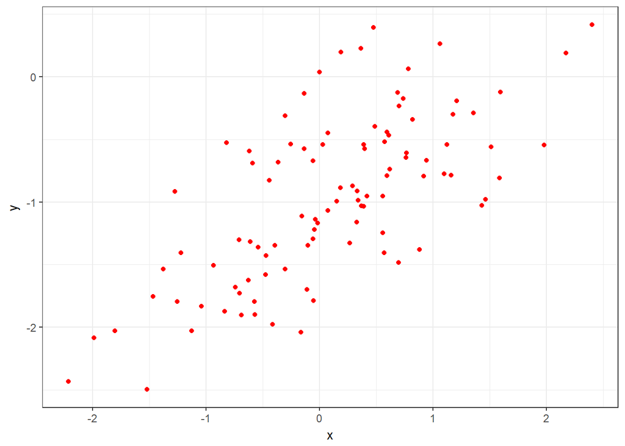

```r
#plot(x,y)
ggplot(aes(x,y),data=data.frame(x,y)) +
  geom_point(color="red") +
  theme_bw()
```

- We have a mostly linear model, with some noise introduced by our `eps` vector of irreducible error.

**(e) Fit a least squares linear model to predict `y` using `x`. Comment on the model obtained. How do $\hat{\beta_0}$ and $\hat{\beta_1}$ compare to $\beta_0$ and $\beta_1$?**

```r
lm_eps <- lm(y~x)
msummary(lm_eps)
```

```
##             Estimate Std. Error t value Pr(>|t|)
## (Intercept) -1.01885    0.04849 -21.010  < 2e-16 ***
## x            0.49947    0.05386   9.273 4.58e-15 ***
##
## Residual standard error: 0.4814 on 98 degrees of freedom
## Multiple R-squared:  0.4674, Adjusted R-squared:  0.4619
## F-statistic: 85.99 on 1 and 98 DF,  p-value: 4.583e-15
```

- They are virtually identical, with *slightly* lower $\hat{\beta_0}$ and $\hat{\beta_1}$ values, which can be rounded to match the true $\beta_p$

**(f) Display the least squares line on the scatterplot obtained in (d). Draw the population regression line on the plot, in a different color. Use the legend() command to create an appropriate legend.**

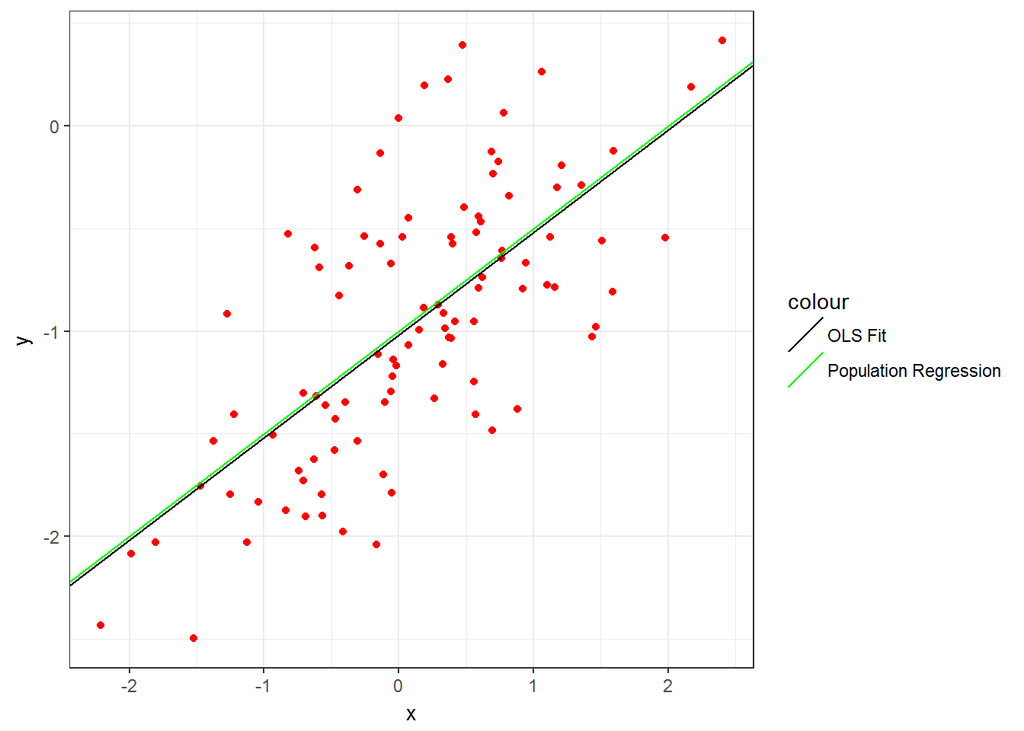

```r
ggplot(aes(x,y),data=data.frame(x,y)) +
  geom_point(color="red") +
  theme_bw() +
  geom_abline(aes(intercept = -1.01885, slope = 0.49947,colour="OLS Fit")) +
  geom_abline(aes(intercept = -1, slope = .5, colour='Population Regression')) +
  scale_colour_manual(values=c("black",'green'))
```

**(g) Now fit a polynomial regression model that predicts $y$ using $x$ and $x^2$. Is there evidence that the quadratic term improves the model fit? Explain your answer.**

```r
lm_poly <- lm(y~poly(x,2))
msummary(lm_poly)
```

```
##             Estimate Std. Error t value Pr(>|t|)
## (Intercept)  -0.9645     0.0479 -20.134  < 2e-16 ***
## poly(x, 2)1   4.4638     0.4790   9.319 3.97e-15 ***
## poly(x, 2)2  -0.6720     0.4790  -1.403    0.164
##
## Residual standard error: 0.479 on 97 degrees of freedom
## Multiple R-squared:  0.4779, Adjusted R-squared:  0.4672
## F-statistic:  44.4 on 2 and 97 DF,  p-value: 2.038e-14
```

- $R^2$ has increased (technically), but the second-order polynomial is not significant, meaning there’s no evidence that the quadratic term improves model fit.

**(h) Repeat (a)-(f) w/ less noise in the data (reduce variance in $\epsilon$ generation). The model $Y = -1 +0.5X + \epsilon$ should remain the same. Describe your results.**

```r
set.seed(1)
x1 <- rnorm(100) # N(0,1) by default
eps1 <- rnorm(100,sd=sqrt(.05))
y1 <- -1 + .5*x1 + eps1
lm_eps1 <- lm(y1~x1)
msummary(lm_eps1)
```

```
##             Estimate Std. Error t value Pr(>|t|)
## (Intercept) -1.00843    0.02169  -46.50   <2e-16 ***
## x1           0.49976    0.02409   20.75   <2e-16 ***
##
## Residual standard error: 0.2153 on 98 degrees of freedom
## Multiple R-squared:  0.8145, Adjusted R-squared:  0.8127
## F-statistic: 430.4 on 1 and 98 DF,  p-value: < 2.2e-16
```

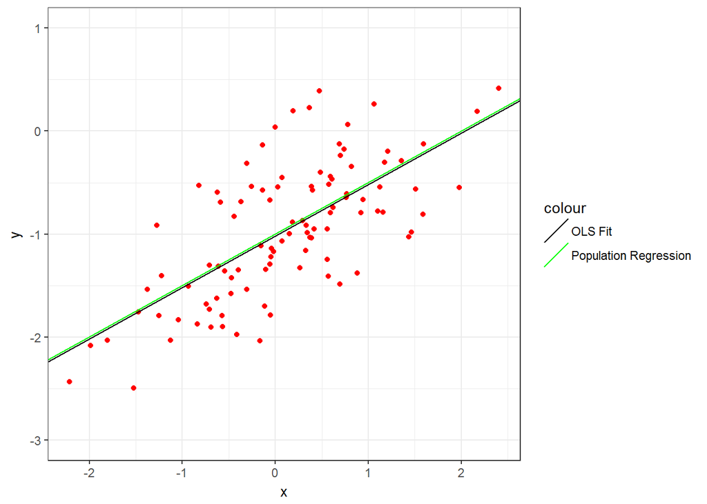

```r
ggplot(aes(x,y),data=data.frame(x,y)) +
  geom_point(color="red") +
  theme_bw() +
  geom_abline(aes(intercept = -1.01885, slope = 0.49947,colour="OLS Fit")) +
  geom_abline(aes(intercept = -1, slope = .5, colour='Population Regression')) +
  scale_colour_manual(values=c("black",'green')) +
  coord_cartesian(ylim=c(-3,1))
```

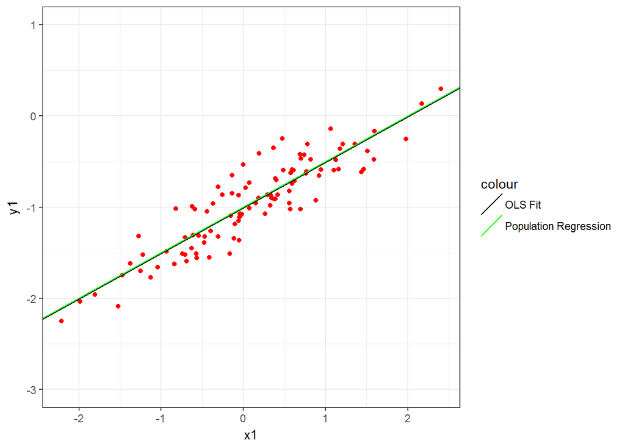

```r
ggplot(aes(x1,y1),data=data.frame(x1,y1)) +
  geom_point(color="red") +
  theme_bw() +
  geom_abline(aes(intercept = -1.00843, slope = 0.49976,colour="OLS Fit")) +
  geom_abline(aes(intercept = -1, slope = .5, colour='Population Regression')) +
  scale_colour_manual(values=c("black",'green')) +
  coord_cartesian(ylim=c(-3,1))
```

- This has moved $\hat{\beta_0}$ and $\hat{\beta_1}$ closer to the true values of $\beta_0$ and $\beta_1$

**(i) Repeat (a)-(f) after modifying the data generation process w/ *more* noise in the data. The model should remain the same (increase variance of the normal distribution used to generate the error term). Describe your results.**

```r
set.seed(1)
x2 <- rnorm(100) # N(0,1) by default
eps2 <- rnorm(100,sd=sqrt(.5))
y2 <- -1 + .5*x2 + eps2
lm_eps2 <- lm(y2~x2)
msummary(lm_eps2)
```

```
##             Estimate Std. Error t value Pr(>|t|)
## (Intercept) -1.02665    0.06858 -14.970  < 2e-16 ***
## x2           0.49925    0.07617   6.554 2.62e-09 ***
##
## Residual standard error: 0.6808 on 98 degrees of freedom
## Multiple R-squared:  0.3047, Adjusted R-squared:  0.2976
## F-statistic: 42.96 on 1 and 98 DF,  p-value: 2.624e-09
```

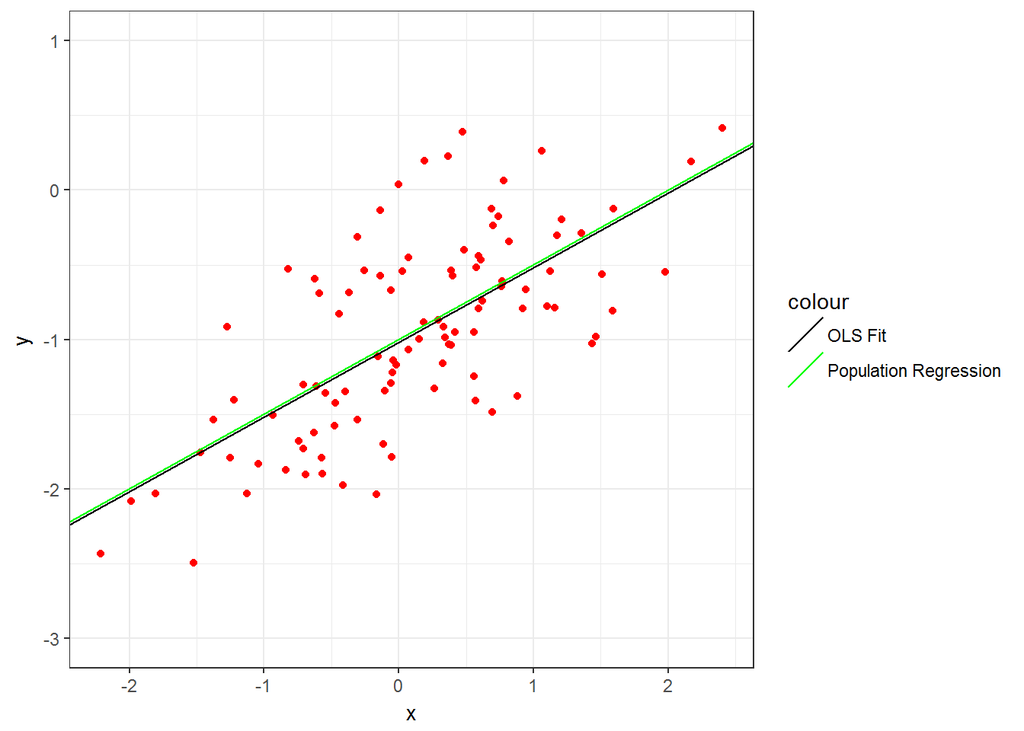

```r
ggplot(aes(x,y),data=data.frame(x,y)) +
  geom_point(color="red") +
  theme_bw() +
  geom_abline(aes(intercept = -1.01885, slope = 0.49947,colour="OLS Fit")) +
  geom_abline(aes(intercept = -1, slope = .5, colour='Population Regression')) +
  scale_colour_manual(values=c("black",'green')) +
  coord_cartesian(ylim=c(-3,1))
```

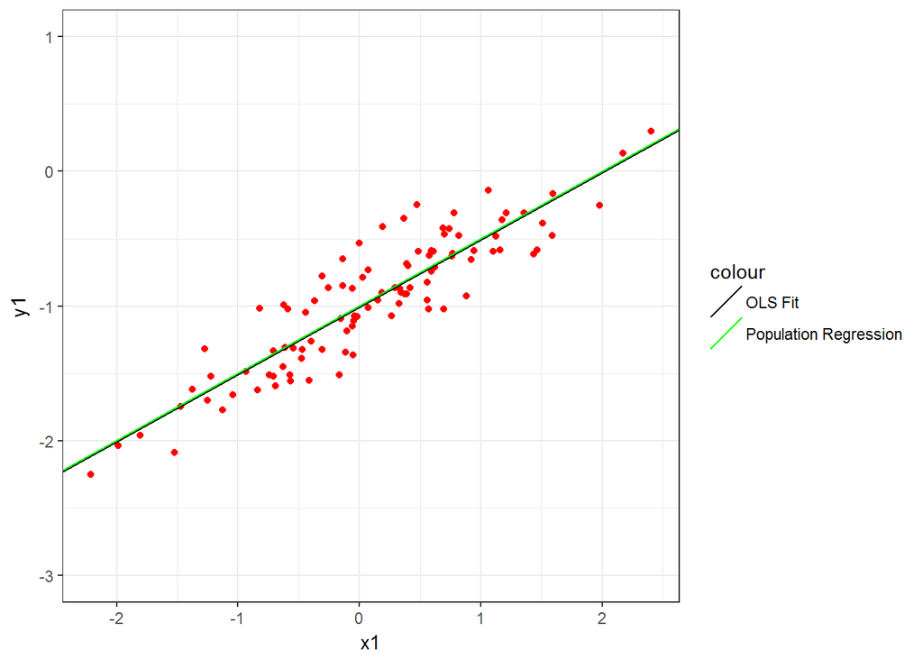

```r
ggplot(aes(x1,y1),data=data.frame(x1,y1)) +
  geom_point(color="red") +
  theme_bw() +
  geom_abline(aes(intercept = -1.00843, slope = 0.49976,colour="OLS Fit")) +
  geom_abline(aes(intercept = -1, slope = .5, colour='Population Regression')) +
  scale_colour_manual(values=c("black",'green')) +
  coord_cartesian(ylim=c(-3,1))
```

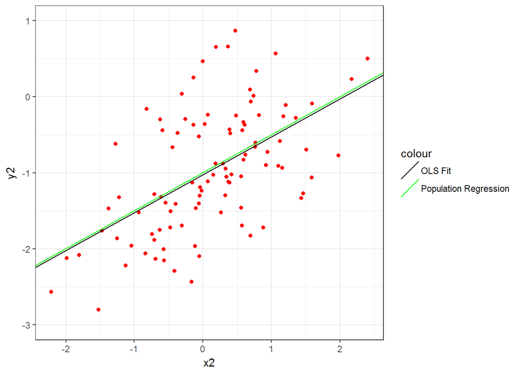

```r
ggplot(aes(x2,y2),data=data.frame(x2,y2)) +
  geom_point(color="red") +
  theme_bw() +
  geom_abline(aes(intercept = -1.02665, slope = 0.49925, colour="OLS Fit")) +
  geom_abline(aes(intercept = -1, slope = .5, colour='Population Regression')) +
  scale_colour_manual(values=c("black",'green')) +
  coord_cartesian(ylim=c(-3,1))
```

- This has moved $\hat{\beta_0}$ and $\hat{\beta_1}$ further from the true values of $\beta_0$ and $\beta_1$

**(j) What are the confidence intervals for $\beta_0$ and $\beta_1$ based on the original, noisier, + less noisy data sets? Comment on your results.**

```r
confint(lm_eps)
```

```
##                  2.5 %     97.5 %
## (Intercept) -1.1150804 -0.9226122
## x            0.3925794  0.6063602
```

```r
confint(lm_eps1)
```

```
##                  2.5 %     97.5 %
## (Intercept) -1.0514655 -0.9653911
## x1           0.4519601  0.5475657
```

```r
confint(lm_eps2)
```

```
##                  2.5 %     97.5 %
## (Intercept) -1.1627482 -0.8905572
## x2           0.3480843  0.6504160
```

- We’ve got a wider CI for both the intercept and the predictor for the noisy set, a narrow CI for the less noisy set (both relative to the original set)

**14. This problem focuses on the collinearity problem.** **(a) Perform the following commands in R:**

```r
set.seed(1)
x1 <- runif(100)
x2 <- 0.5*x1 + rnorm(100)/10
y <- 2 + 2*x1 + 0.3*x2 + rnorm(100)
```

**The last line corresponds to creating a linear model in which $y$ = a function of $x_1$ + $x_2$ Write out the form of the linear model. What are the regression coefficients?**

**(b) What is the correlation between $x_1$ and $x_2$? Create a scatterplot displaying the relationship between the variables.**

```r
cor(x1,x2)
```

```
## [1] 0.8351212
```

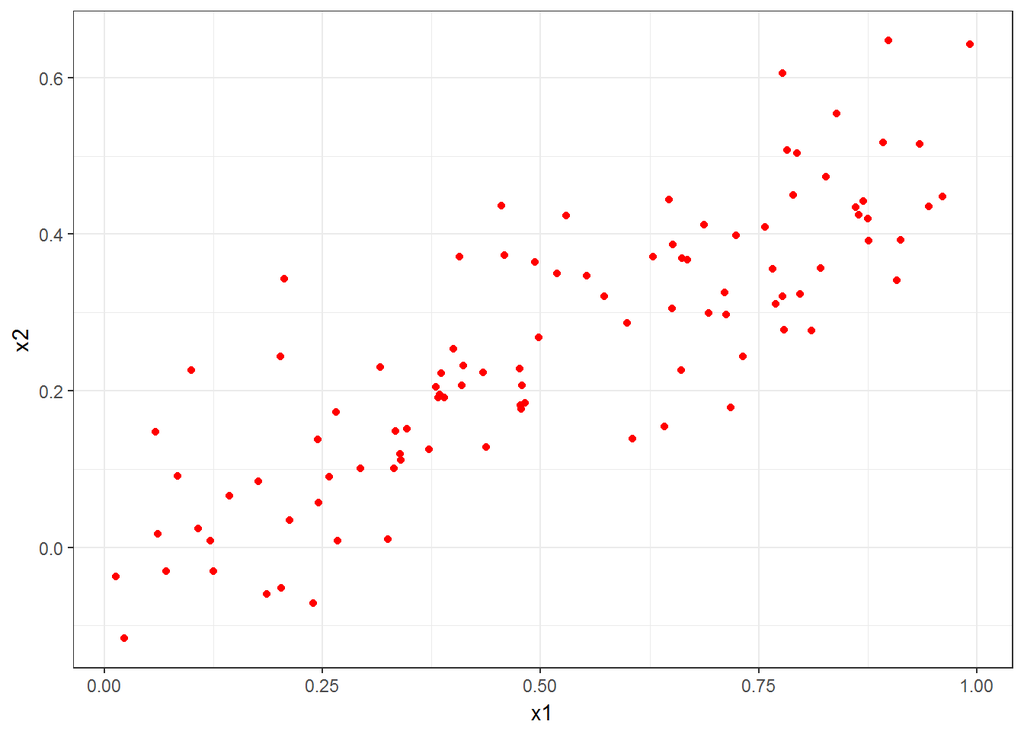

```r
ggplot(aes(x1,x2),data=data.frame(x1,x2)) +
  geom_point(color="red") +
  theme_bw()
```

- There’s a pretty strong positive correlation between both predictors

**(c) Using this data, fit a least squares regression to predict $y$ using $x_1$ and $x_2$. Describe the results obtained. What are $\hat{\beta_0}, \hat{\beta_1}, \hat{\beta_2}$? How do these relate to the true $\beta_0, \beta_1, \beta_2$? Can you reject $H_01: \beta_1 = 0$? How about the $H_02: \beta_2 = 0$?**

```r
lm_14 <- lm(y~x1+x2)
msummary(lm_14)
```

```
##             Estimate Std. Error t value Pr(>|t|)
## (Intercept)   2.1305     0.2319   9.188 7.61e-15 ***
## x1            1.4396     0.7212   1.996   0.0487 *
## x2            1.0097     1.1337   0.891   0.3754
##
## Residual standard error: 1.056 on 97 degrees of freedom
## Multiple R-squared:  0.2088, Adjusted R-squared:  0.1925
## F-statistic:  12.8 on 2 and 97 DF,  p-value: 1.164e-05
```

- Our $\hat{\beta_0}$ has slightly increased from 2 to 2.1305, while our $\hat{\beta_1}$ has decreased by over .5 from 2 down to 1.4396, while $\hat{\beta_3}$ has increased from .3 to 1.0097. We cannot reject the null $H_{02}: \beta_2 = 0$, but we *may* be able to reject the null $H_{01}: \beta_1 = 0$, depending on our threshold for doing so (is 1 `*` enough?)

**(d) Now fit a least squares regression to predict $y$ using only $x_1$. Comment on your results. Can you reject $H_{01}: \beta_1 = 0$?**

```r
lm_14_2 <- lm(y~x1)
msummary(lm_14_2)
```

```
##             Estimate Std. Error t value Pr(>|t|)
## (Intercept)   2.1124     0.2307   9.155 8.27e-15 ***
## x1            1.9759     0.3963   4.986 2.66e-06 ***
##
## Residual standard error: 1.055 on 98 degrees of freedom
## Multiple R-squared:  0.2024, Adjusted R-squared:  0.1942
## F-statistic: 24.86 on 1 and 98 DF,  p-value: 2.661e-06
```

- Now we can reject $H_{01}: \beta_1 = 0$

**(e) Now fit a least squares regression to predict $y$ using only $x_2$. Comment on your results. Can you reject the null $H_{01}: \beta_1 = 0$?**

```r
lm_14_3 <- lm(y~x2)
msummary(lm_14_3)
```

```
##             Estimate Std. Error t value Pr(>|t|)
## (Intercept)   2.3899     0.1949   12.26  < 2e-16 ***
## x2            2.8996     0.6330    4.58 1.37e-05 ***
##
## Residual standard error: 1.072 on 98 degrees of freedom
## Multiple R-squared:  0.1763, Adjusted R-squared:  0.1679
## F-statistic: 20.98 on 1 and 98 DF,  p-value: 1.366e-05
```

- Now we can reject $H_{02}: \beta_2 = 0$

**(f) Do the results obtained in (c)-(e) contradict each other? Explain your answer.**

- No, each predictor can only influence the response in isolation, with no other effects from the other predictors.
- **We know this because $r_{x_1,x_2}$ = .835, i.e .$x_1$ and $x_2$ are collinear**
- Therefore, we cannot (or it is difficult to) distinguish the individual effects of each predictor in isolation that we are actually able see in the simple linear models with 1 predictor

**(g) Now suppose we obtain one additional observation, which was unfortunately mismeasured.**

```r
x1 <- c(x1, 0.1)
x2 <- c(x2, 0.8)
y <- c(y,6)
```

**Re-fit the linear models from (c) to (e) using this new data. What effect does this new observation have on the each of the models? In each model, is this observation an outlier? A high-leverage point? Both? Explain your answers.**

```r
lm_14_new <- lm(y~x1+x2)
msummary(lm_14_new)
```

```
##             Estimate Std. Error t value Pr(>|t|)
## (Intercept)   2.2267     0.2314   9.624 7.91e-16 ***
## x1            0.5394     0.5922   0.911  0.36458
## x2            2.5146     0.8977   2.801  0.00614 **
##
## Residual standard error: 1.075 on 98 degrees of freedom
## Multiple R-squared:  0.2188, Adjusted R-squared:  0.2029
## F-statistic: 13.72 on 2 and 98 DF,  p-value: 5.564e-06
```

```r
msummary(lm_14)
```

```
##             Estimate Std. Error t value Pr(>|t|)
## (Intercept)   2.1305     0.2319   9.188 7.61e-15 ***
## x1            1.4396     0.7212   1.996   0.0487 *
## x2            1.0097     1.1337   0.891   0.3754
##
## Residual standard error: 1.056 on 97 degrees of freedom
## Multiple R-squared:  0.2088, Adjusted R-squared:  0.1925
## F-statistic:  12.8 on 2 and 97 DF,  p-value: 1.164e-05
```

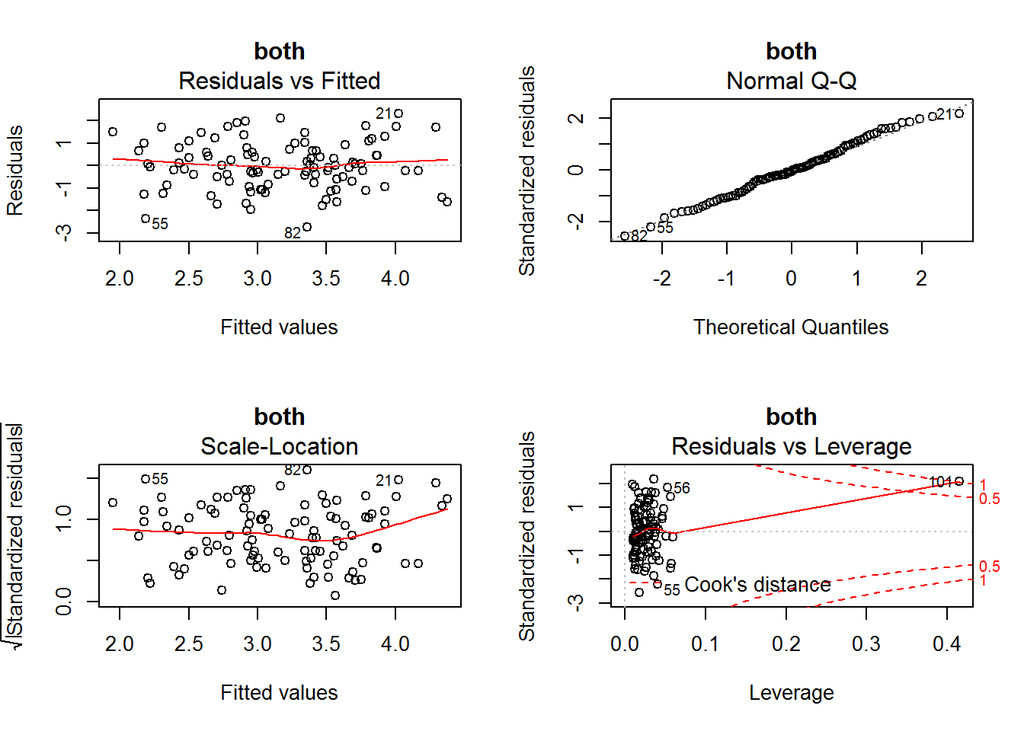

```r
par(mfrow=c(2,2))
plot(lm_14_new,main="both")
```

```r
lm_14_new_2 <- lm(y~x1)
summary(lm_14_new_2)
```

```
##
## Call:
## lm(formula = y ~ x1)
##
## Residuals:
##     Min      1Q  Median      3Q     Max
## -2.8897 -0.6556 -0.0909  0.5682  3.5665
##
## Coefficients:
##             Estimate Std. Error t value Pr(>|t|)
## (Intercept)   2.2569     0.2390   9.445 1.78e-15 ***
## x1            1.7657     0.4124   4.282 4.29e-05 ***
## ---
## Signif. codes:  0 '***' 0.001 '**' 0.01 '*' 0.05 '.' 0.1 ' ' 1
##
## Residual standard error: 1.111 on 99 degrees of freedom
## Multiple R-squared:  0.1562, Adjusted R-squared:  0.1477
## F-statistic: 18.33 on 1 and 99 DF,  p-value: 4.295e-05
```

```r
msummary(lm_14)
```

```
##             Estimate Std. Error t value Pr(>|t|)
## (Intercept)   2.1305     0.2319   9.188 7.61e-15 ***
## x1            1.4396     0.7212   1.996   0.0487 *
## x2            1.0097     1.1337   0.891   0.3754
##
## Residual standard error: 1.056 on 97 degrees of freedom
## Multiple R-squared:  0.2088, Adjusted R-squared:  0.1925
## F-statistic:  12.8 on 2 and 97 DF,  p-value: 1.164e-05
```

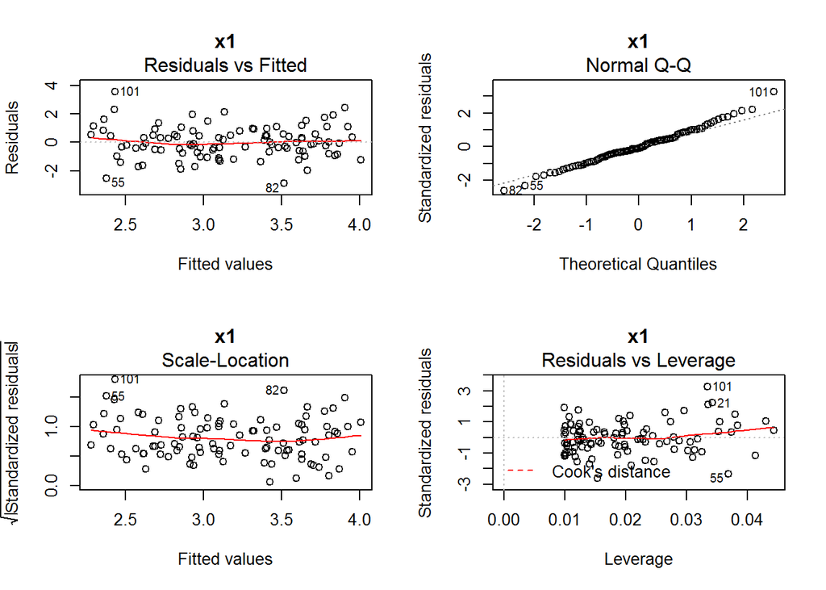

```r
par(mfrow=c(2,2))
plot(lm_14_new_2,main="x1")
```

```r
lm_14_new_3 <- lm(y~x2)
summary(lm_14_new_3)
```

```
##
## Call:
## lm(formula = y ~ x2)
##
## Residuals:
##      Min       1Q   Median       3Q      Max
## -2.64729 -0.71021 -0.06899  0.72699  2.38074
##
## Coefficients:
##             Estimate Std. Error t value Pr(>|t|)
## (Intercept)   2.3451     0.1912  12.264  < 2e-16 ***
## x2            3.1190     0.6040   5.164 1.25e-06 ***
## ---
## Signif. codes:  0 '***' 0.001 '**' 0.01 '*' 0.05 '.' 0.1 ' ' 1
##
## Residual standard error: 1.074 on 99 degrees of freedom
## Multiple R-squared:  0.2122, Adjusted R-squared:  0.2042
## F-statistic: 26.66 on 1 and 99 DF,  p-value: 1.253e-06
```

```r
msummary(lm_14)
```

```
##             Estimate Std. Error t value Pr(>|t|)
## (Intercept)   2.1305     0.2319   9.188 7.61e-15 ***
## x1            1.4396     0.7212   1.996   0.0487 *
## x2            1.0097     1.1337   0.891   0.3754
##
## Residual standard error: 1.056 on 97 degrees of freedom
## Multiple R-squared:  0.2088, Adjusted R-squared:  0.1925
## F-statistic:  12.8 on 2 and 97 DF,  p-value: 1.164e-05
```

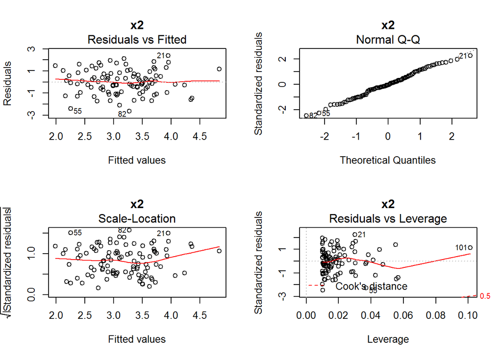

```r
par(mfrow=c(2,2))
plot(lm_14_new_3,main="x2")
```

- It now appears that we can see some individual effect from $x_2$ in the multiple linear regression model (as opposed to $x_1$ in the original multiple regression), while both individual effects are still clearly visible in the simple models.
- $R^2$ has increased in the multiple model and the $x_2$ model, but decreased in the $x_1$ model
- Looking at the $x_1$ plots, we see that observation 101 is indeed an outlier (Residuals vs. leverage), and that it’s fitted quantiles is “too large”, indicating an overestimation.
- We can also see it clearly annotated in the residuals vs. fitted and scale-location plots as an outlier (>2 or <-2)
- It is a high-leverage point for the $x_2$ model, as well as in the multiple regression.

**15. Using Boston data set, try to predict per capita crime rate using the other variables in this data set. In other words, per capita crime rate is the response, and the other variables are the predictors.** **(a) For each predictor, fit a simple linear regression model to predict the response. Describe your results. In which of the models is there a statistically significant association between the predictor and the response? Create some plots to back up your assertions.**

```r
library(broom)
library(MASS)
names <- names(Boston)
names <- names[2:length(names)]

df_singles <- as.data.frame(data_frame(formula = paste('crim ~', names),
           model = map(formula, lm, data = Boston))) %>%
  mutate(tidied = map(model, tidy)) %>%
  unnest(tidied) %>%
  mutate(significant = if_else(p.value < .001,"***",
                                 if_else(p.value < .01,"**",
                                         if_else(p.value < .05,"*","no"))))
(df_singles <- df_singles %>% filter(!term=="(Intercept)"))
```

```
##           formula    term    estimate   std.error statistic      p.value
## 1       crim ~ zn      zn -0.07393498 0.016094596 -4.593776 5.506472e-06
## 2    crim ~ indus   indus  0.50977633 0.051024332  9.990848 1.450349e-21
## 3     crim ~ chas    chas -1.89277655 1.506115484 -1.256727 2.094345e-01
## 4      crim ~ nox     nox 31.24853120 2.999190381 10.418989 3.751739e-23
## 5       crim ~ rm      rm -2.68405122 0.532041083 -5.044819 6.346703e-07
## 6      crim ~ age     age  0.10778623 0.012736436  8.462825 2.854869e-16
## 7      crim ~ dis     dis -1.55090168 0.168330031 -9.213458 8.519949e-19
## 8      crim ~ rad     rad  0.61791093 0.034331820 17.998199 2.693844e-56
## 9      crim ~ tax     tax  0.02974225 0.001847415 16.099388 2.357127e-47
## 10 crim ~ ptratio ptratio  1.15198279 0.169373609  6.801430 2.942922e-11
## 11   crim ~ black   black -0.03627964 0.003873154 -9.366951 2.487274e-19
## 12   crim ~ lstat   lstat  0.54880478 0.047760971 11.490654 2.654277e-27
## 13    crim ~ medv    medv -0.36315992 0.038390175 -9.459710 1.173987e-19
##    significant
## 1          ***
## 2          ***
## 3           no
## 4          ***
## 5          ***
## 6          ***
## 7          ***
## 8          ***
## 9          ***
## 10         ***
## 11         ***
## 12         ***
## 13         ***
```

- Each variable, in isolation, has a statistically significant association with the response `crim` *except* for being on the Charles River (`chas`).

**(b) Fit a multiple regression model to predict the response using all of the predictors. Describe your results. For which predictors can we reject $H_{0j} = \beta_j = 0$?**

```r
fullBostonCrim <- lm(crim~.,Boston)
summary(fullBostonCrim)
```

```
##
## Call:
## lm(formula = crim ~ ., data = Boston)
##
## Residuals:
##    Min     1Q Median     3Q    Max
## -9.924 -2.120 -0.353  1.019 75.051
##
## Coefficients:
##               Estimate Std. Error t value Pr(>|t|)
## (Intercept)  17.033228   7.234903   2.354 0.018949 *
## zn            0.044855   0.018734   2.394 0.017025 *
## indus        -0.063855   0.083407  -0.766 0.444294
## chas         -0.749134   1.180147  -0.635 0.525867
## nox         -10.313535   5.275536  -1.955 0.051152 .
## rm            0.430131   0.612830   0.702 0.483089
## age           0.001452   0.017925   0.081 0.935488
## dis          -0.987176   0.281817  -3.503 0.000502 ***
## rad           0.588209   0.088049   6.680 6.46e-11 ***
## tax          -0.003780   0.005156  -0.733 0.463793
## ptratio      -0.271081   0.186450  -1.454 0.146611
## black        -0.007538   0.003673  -2.052 0.040702 *
## lstat         0.126211   0.075725   1.667 0.096208 .
## medv         -0.198887   0.060516  -3.287 0.001087 **
## ---
## Signif. codes:  0 '***' 0.001 '**' 0.01 '*' 0.05 '.' 0.1 ' ' 1
##
## Residual standard error: 6.439 on 492 degrees of freedom
## Multiple R-squared:  0.454,  Adjusted R-squared:  0.4396
## F-statistic: 31.47 on 13 and 492 DF,  p-value: < 2.2e-16
```

- The variables for which we can reject the null $H_{0j} = \beta_j = 0$ are `rad`, `dis`, less so `medv`, and less so `zn`, `black`.
- So, looking at the coefficients, we can see that an increase of 1 unit in the index of accessibility to radial highways would increase per capita crime rate by .588 units, an increase of 1 unit in the weighted mean of distances to five Boston employment centres would decrease per capita crime rate by .987 units, and an increase in in median home value of $1K would mean a decrease of .198 units for crime rate.

**(c) How do results from (a) compare to results from (b)? Create a plot displaying univariate regression coefficients from (a) on x-axis, + multiple regression coefficients from (b) on y-axis (i.e. each predictor is displayed as a single DP)**

- The multiple linear regression has eliminated signicant associations indicated by the simple linear regression models for `indus`, `nox`, `rm`, `age`, `tax`, `ptratio`, and `lstat`, and decreased the significance of `zn`, `black`, and `medv`, and for `dis` and `rad` (but these last 3 are still significant)

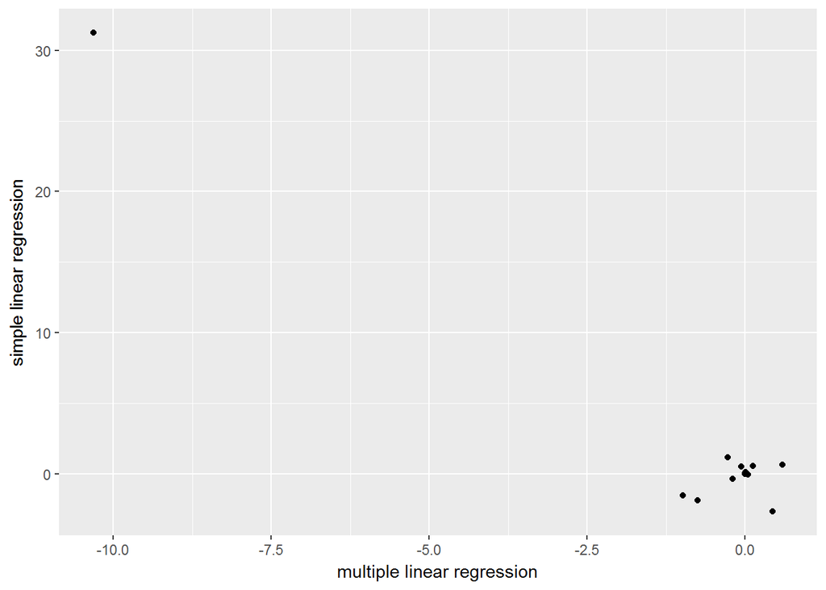

```r
simpEstimate <- fullBostonCrim$coefficients[2:length(fullBostonCrim$coefficients)]
coeffs <- df_singles %>%
  filter(!term=="(Intercept)") %>%
  dplyr::select(term,estimate) %>%
  mutate(multEstimate = estimate
         ,simpEstimate = simpEstimate) %>%
  dplyr::select(-estimate)

ggplot(coeffs,aes(simpEstimate,multEstimate)) +
  xlab('multiple linear regression') +
  ylab('simple linear regression') +
  geom_point()
```

**(d) Is there evidence of non-linear association between any of the predictors + the response? To answer this question, for each predictor X, fit a model of the form $Y = \hat{\beta_0} + \hat{\beta_1}X + \hat{\beta_2}X^2 + \hat{\beta_3}X^3 + \epsilon$**

```r
df <- as.data.frame(data_frame(formula = paste('crim ~ ', names, " + I(", names, "^2)", " + I(", names, "^3)", sep=""),
                         model = map(formula, lm, data = Boston))) %>%
  mutate(tidied = map(model, tidy)) %>%
  unnest(tidied) %>%
  mutate(significant = if_else(p.value < .001,"***",
                                 if_else(p.value < .01,"**",
                                         if_else(p.value < .05,"*","no"))))
df %>% filter(!term=="(Intercept)")
```

```
##                                         formula         term      estimate
## 1                 crim ~ zn + I(zn^2) + I(zn^3)           zn -3.321884e-01
## 2                 crim ~ zn + I(zn^2) + I(zn^3)      I(zn^2)  6.482634e-03
## 3                 crim ~ zn + I(zn^2) + I(zn^3)      I(zn^3) -3.775793e-05
## 4        crim ~ indus + I(indus^2) + I(indus^3)        indus -1.965213e+00
## 5        crim ~ indus + I(indus^2) + I(indus^3)   I(indus^2)  2.519373e-01
## 6        crim ~ indus + I(indus^2) + I(indus^3)   I(indus^3) -6.976009e-03
## 7           crim ~ chas + I(chas^2) + I(chas^3)         chas -1.892777e+00
## 8              crim ~ nox + I(nox^2) + I(nox^3)          nox -1.279371e+03
## 9              crim ~ nox + I(nox^2) + I(nox^3)     I(nox^2)  2.248544e+03
## 10             crim ~ nox + I(nox^2) + I(nox^3)     I(nox^3) -1.245703e+03
## 11                crim ~ rm + I(rm^2) + I(rm^3)           rm -3.915014e+01
## 12                crim ~ rm + I(rm^2) + I(rm^3)      I(rm^2)  4.550896e+00
## 13                crim ~ rm + I(rm^2) + I(rm^3)      I(rm^3) -1.744770e-01
## 14             crim ~ age + I(age^2) + I(age^3)          age  2.736531e-01
```

[output cut: 61 more lines]

- It appears that `indus`, `nox`, `dis`, `medv`, less so, `ptratio`, and (barely) `age` have a non-linear relationship with `crim`